# Discrete Event Simulation

YUNWEI HU

2022-07-23

This is a repost of the bolg by me dated 2018-05-21.

```r
#prepare the libraries
library(tidyverse)
library(simmer)
library(simmer.plot)
library(intervals)
```

## Simmer for R

In my short experiment with Simpy and Simmer, Simmer shines in one area: monitoring. In Simpy a list can be passed to the simulation, and it is flexible to choose what to code.

With Simmer, three commands `get_mon_arrivals()`, `get_mon_attributes()`, `get_mon_resources()` can generate the story book of the simulation. The story is in data.frame format, and can be easily processed in R.

Let’s use the Machine Shop as an Example.

Instead of print out the events in user interface with `log_()`, we make the simulation `invisible`, and add an attribute to log the state (working, fail).

```r
machine <- function(mttf, repair_time){
      machie <- trajectory() %>%
      # machine_state: 1-working, 0-fail
      set_attribute("machine_state", 1) %>%
        timeout(function() rexp(1, 1/mttf)) %>%
        set_attribute("machine_state", -1, mod="+") %>%
        seize("repairman") %>%
        timeout(repair_time) %>%
        release("repairman") %>%
        set_attribute("machine_state", 1, mod="+") %>%
        rollback(6)
  }
plot(machine(10,1))
```

[interactive chart not shown]

Make it a function.

```r
simmer_relia <- function(sim_time, mon_ = "attributes") {
  env <- simmer() %>%
  # use resource to track system state
  # all items in series will require same "repair" resource.
  # set capacity to inf, assuming no queue for repair
  # if repair resource busy -> system down
  # for n-oo-k items, if resource server > k-n ->system down
  add_resource("repairman", capacity = Inf) %>%
  add_generator("machine_a", machine(100, 10), at(0), mon = 2) %>%
  add_generator("machine_b", machine(100, 5), at(0), mon = 2) %>%
  run(sim_time) %>%
  invisible
  if (mon_=="resources"){
    sim_log <- get_mon_resources(env)
  } else if (mon_=="attributes") {
    sim_log <- get_mon_attributes(env)
  }
  sim_log
}
```

### Loop for replications

```r
N_RUN <-  10
SIM_END = 500
ptm <- proc.time()
machine_state_log <- 1:N_RUN %>%
  map_df(function(x) cbind(simmer_relia(SIM_END), tibble(i_run = x)))
simmer_time <- proc.time() - ptm
tail(machine_state_log)
```

```
##         time       name           key value replication i_run
## 200 372.5198 machine_a0 machine_state     0           1    10
## 201 382.5198 machine_a0 machine_state     1           1    10
## 202 457.5239 machine_a0 machine_state     0           1    10
## 203 467.5239 machine_a0 machine_state     1           1    10
## 204 487.1744 machine_b0 machine_state     0           1    10
## 205 492.1744 machine_b0 machine_state     1           1    10
```

Test

```r
simu_attributes <- simmer_relia(500)
print(simu_attributes)
```

```
##          time       name           key value replication
## 1    0.000000 machine_a0 machine_state     1           1
## 2    0.000000 machine_b0 machine_state     1           1
## 3    2.083801 machine_b0 machine_state     0           1
## 4    7.083801 machine_b0 machine_state     1           1
## 5   19.950400 machine_a0 machine_state     0           1
## 6   28.061391 machine_b0 machine_state     0           1
## 7   29.950400 machine_a0 machine_state     1           1
## 8   33.061391 machine_b0 machine_state     1           1
## 9   93.129100 machine_a0 machine_state     0           1
## 10 103.129100 machine_a0 machine_state     1           1
## 11 115.875531 machine_a0 machine_state     0           1
## 12 125.875531 machine_a0 machine_state     1           1
## 13 146.544578 machine_b0 machine_state     0           1
## 14 151.544578 machine_b0 machine_state     1           1
## 15 180.074790 machine_b0 machine_state     0           1
## 16 185.074790 machine_b0 machine_state     1           1
## 17 333.480556 machine_b0 machine_state     0           1
## 18 338.167185 machine_a0 machine_state     0           1
## 19 338.480556 machine_b0 machine_state     1           1
## 20 348.167185 machine_a0 machine_state     1           1
## 21 369.056606 machine_b0 machine_state     0           1
## 22 374.056606 machine_b0 machine_state     1           1
## 23 385.352809 machine_a0 machine_state     0           1
## 24 395.352809 machine_a0 machine_state     1           1
## 25 483.050025 machine_a0 machine_state     0           1
## 26 493.050025 machine_a0 machine_state     1           1
```

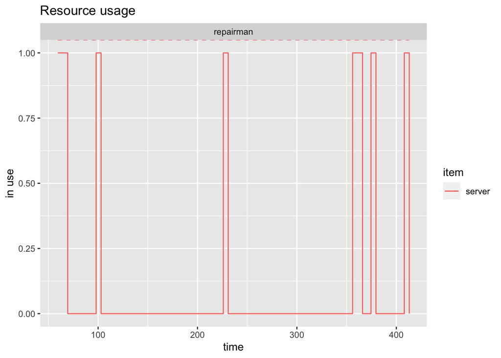

```r
simu_resources <- simmer_relia(500, mon = "resources")
plot(simu_resources, metric = "usage", "repairman", items = "server", steps = TRUE)
```

# Monitoring: resources vs attributes

With simmer, by adding user-defined attributes, we can log the simualtion flexibly. In the context of the system reliability, since only one “repariman” resource is requested when ANY of the machines fail, the “repairman” resource can be used directly for simple system reliability metrics. If the it is series system, whenever the repairman is busy, the system is down. Or it is n-out-of-k, then >= n simultaneous “repairs” implies system down.

The attribute logs the state of all the “machines”, it is more flexible to use the attributes. We are interest in the event sequence of the system down time, the `Intervals` pacakge, which provides a collections of operation on intervals over the real number line (R), is helpful the determine the system state base on the component state.

In the example above, we have the event sequence of the machine_a and machine_b, so for a parellel system, the intersection of downtime interval is the system down time. and for a series system, union.

### Convert event sequences to state intervals

```r
machine_state_interval <- function(machine_state_log){
  machine_state_log %>%
    group_by(i_run, name) %>%
    arrange(time) %>%
    # end_time is lead(start_time) (remove leading NA), last one is sim_end
    mutate(end_time = c(head(lead(time), -1), SIM_END)) %>%
    ungroup() %>%
    dplyr::select(name, value, start_time = time, end_time, i_run) %>%
    arrange(i_run, name, start_time)
}

state_interval <- machine_state_interval(machine_state_log)

machine_down_interval <- function(state_interval, i, machine_name){
  fail_log <- state_interval %>%
    filter(i_run == i, name == machine_name) %>%
    filter(value == 0)
  Intervals(matrix(c(fail_log$start_time,fail_log$end_time), ncol = 2))
}
```

### parallel -> intersection of the interval

```r
parallel_down_log <- tibble(start_time = as.numeric(), end_time = as.numeric(), i_run = as.integer())

for (i in 1:N_RUN){
  parallel_down_interval <- interval_intersection(
    machine_down_interval(state_interval, i, "machine_a0"),
    machine_down_interval(state_interval, i, "machine_b0") )
  if(length(parallel_down_interval) > 0){
    print(i)
    print(parallel_down_interval)
    parallel_down_log <- rbind(parallel_down_log,
                            cbind(as.matrix(parallel_down_interval), tibble(i_run = i)))
  }
}
```

```
## [1] 2
## Object of class Intervals
## 1 interval over R:
## [466.504327321385, 467.032218134197]
## [1] 3
## Object of class Intervals
## 2 intervals over R:
## [345.341762365729, 346.616392690741]
## [353.097509328329, 355.341762365729]
## [1] 4
## Object of class Intervals
## 2 intervals over R:
## [6.27613738179207, 8.62729276530445]
## [363.7315009916, 368.7315009916]
## [1] 5
## Object of class Intervals
## 1 interval over R:
## [71.7694460907352, 71.9605029281229]
## [1] 7
## Object of class Intervals
## 1 interval over R:
## [157.120866561418, 158.066007353948]
## [1] 10
## Object of class Intervals
## 1 interval over R:
## [303.896617225544, 304.576073745808]
```

```r
names(parallel_down_log) <- c("start", "end", "i_run")
print(parallel_down_log)
```

```
##        start        end i_run
## 1 466.504327 467.032218     2
## 2 345.341762 346.616393     3
## 3 353.097509 355.341762     3
## 4   6.276137   8.627293     4
## 5 363.731501 368.731501     4
## 6  71.769446  71.960503     5
## 7 157.120867 158.066007     7
## 8 303.896617 304.576074    10
```

### Series -> union of the interval

```r
series_down_log <- tibble(start_time = as.numeric(), end_time = as.numeric(), i_run = as.integer())

for (i in 1:N_RUN){
  series_down_interval <- interval_union(
    machine_down_interval(state_interval, i, "machine_a0"),
    machine_down_interval(state_interval, i, "machine_b0") )
  if(length(series_down_interval) > 0){
    series_down_log <- rbind(series_down_log,
                             cbind(as.matrix(series_down_interval), tibble(i_run = i)))
  }
}
names(series_down_log) <- c("start", "end", "i_run")
head(series_down_log,20)
```

```
##        start       end i_run
## 1   85.92645  90.92645     1
## 2  111.64986 121.64986     1
## 3  144.79305 149.79305     1
## 4  181.30955 191.30955     1
## 5  275.61709 280.61709     1
## 6  376.61653 381.61653     1
## 7  383.16460 393.16460     1
## 8  396.93095 401.93095     1
## 9  481.44265 486.44265     1
## 10 496.60298 500.00000     1
## 11  55.87835  60.87835     2
## 12 186.47189 196.47189     2
## 13 259.49620 264.49620     2
## 14 264.78493 274.78493     2
## 15 457.03222 471.50433     2
## 16  53.69706  63.69706     3
## 17  84.48646  89.48646     3
## 18 115.38496 120.38496     3
## 19 217.76410 222.76410     3
## 20 258.89103 263.89103     3
```